# PPG Paint Colors: Final Project - Part 2

Alaa Alghwiri

# 1. Set up the environment

```r
easypackages::libraries("here", "tidyverse", "viridisLite", "ggdist",
                        "distributional", "ggridges", "ggpubr", "yardstick",
                        "rstanarm", "caret")
```

```
## here() starts at /Users/alghwiri/Library/CloudStorage/OneDrive-UniversityofPittsburgh/Drive Back-up/Acadmics/HDS masters/Taken Courses/Machine Learning
```

[output not shown]

# 2. Data prep

```r
df_orig <- read_csv(here("Final project/Submit/paint_train_split.csv"))
```

```
## ──────────────────────────────────────────────────────── Delimiter: "," chr
## (2): Lightness, Saturation dbl (7): ...1, R, G, B, Hue, response, outcome
```

```r
df <- df_orig %>%
  mutate(y = boot::logit( (response - 0) / (100 - 0) )) %>%
  select(R, G, B, Lightness, Saturation, Hue, y) %>%
  mutate_at(c("R", "G", "B", "Hue"), ~(scale(.) %>% as.vector))

df %>% summary()
```

```
##        R                 G                 B            Lightness
##  Min.   :-3.2078   Min.   :-2.3696   Min.   :-2.0652   Length:751
##  1st Qu.:-0.6307   1st Qu.:-0.7562   1st Qu.:-0.8684   Class :character
##  Median : 0.3160   Median : 0.2359   Median : 0.1640   Mode  :character
##  Mean   : 0.0000   Mean   : 0.0000   Mean   : 0.0000
##  3rd Qu.: 0.8068   3rd Qu.: 0.9073   3rd Qu.: 0.9315
##  Max.   : 1.2627   Max.   : 1.2981   Max.   : 1.4248
##   Saturation             Hue                 y
##  Length:751         Min.   :-1.65312   Min.   :-2.75154
##  Class :character   1st Qu.:-0.85710   1st Qu.:-1.04597
##  Mode  :character   Median :-0.06108   Median : 0.04001
##                     Mean   : 0.00000   Mean   :-0.11498
##                     3rd Qu.: 0.83444   3rd Qu.: 0.94446
##                     Max.   : 1.82947   Max.   : 1.81529
```

Also, for validation purposes, we split the data into training and testing sets:

```r
set.seed(0)
train_id <- sample(1:nrow(df), size = floor(0.8 * nrow(df)))
df_train <- df %>% slice(train_id)
df_test <- df %>% slice(-train_id)
```

# 3. Linear models

## 3.1 Fitting Linear Models

We declare and train the 10 models, 7 described in the instructions. Due to the random nature in this process, we set the randomizer seed to 0 for all chunks below:

```r
set.seed(0)
mod01 <- lm(y ~ 1, data = df_train) # Intercept only
mod02 <- lm(y ~ Lightness + Saturation, data = df_train) # Categorical variables only
mod03 <- lm(y ~ R + G + B + Hue, data = df_train) # Continuous variables only
mod04 <- lm(y ~ R + G + B + Hue + Lightness + Saturation, data = df_train) # All categorical and continuous variables
mod05 <- lm(y ~ (R + G + B + Hue) * (Lightness + Saturation), data = df_train) # Interaction of categorical inputs with continuous inputs main effects
mod06 <- lm(y ~ (R + G + B + Hue)^2 + Lightness + Saturation, data = df_train) # Categorical inputs, main effect and all pairwise interactions
mod07 <- lm(y ~ (R + G + B + Hue)^2 * (Lightness + Saturation), data = df_train) # Interaction of categorical inputs with main effect and all pairwise interactions
```

And the 3 with non-linear basis functions. We have established in Part 1 that the relationship between Hue (H) and y is probably non-linear. Since we have established RGB data are highly correlated, we include pair-wise interactions between them:

```r
mod08 <- lm(y ~ ( (R + G + B)^2 + splines::ns(Hue, 2) ) * (Lightness + Saturation), data = df_train) # Non linear basis functions
mod09 <- lm(y ~ (R + G + B)^2 * splines::ns(Hue, 2) + (Lightness + Saturation), data = df_train) # Interactions of basis functions with other basis functions
mod10 <- lm(y ~ (R + G + B)^2 + splines::ns(Hue, 2) * (Lightness * Saturation), data = df_train) # Interactions of basis functions with the categorical inputs
```

## 3.2 Model evaluation

First, we provide a view of common metrics, including R squared, AIC and BIC.

```r
models <- list(mod01, mod02, mod03, mod04, mod05, mod06, mod07, mod08, mod09, mod10)
metrics <- models %>%
  purrr::map_df(broom::glance) %>%
  mutate(model_name = 1:10)
```

For R squared:

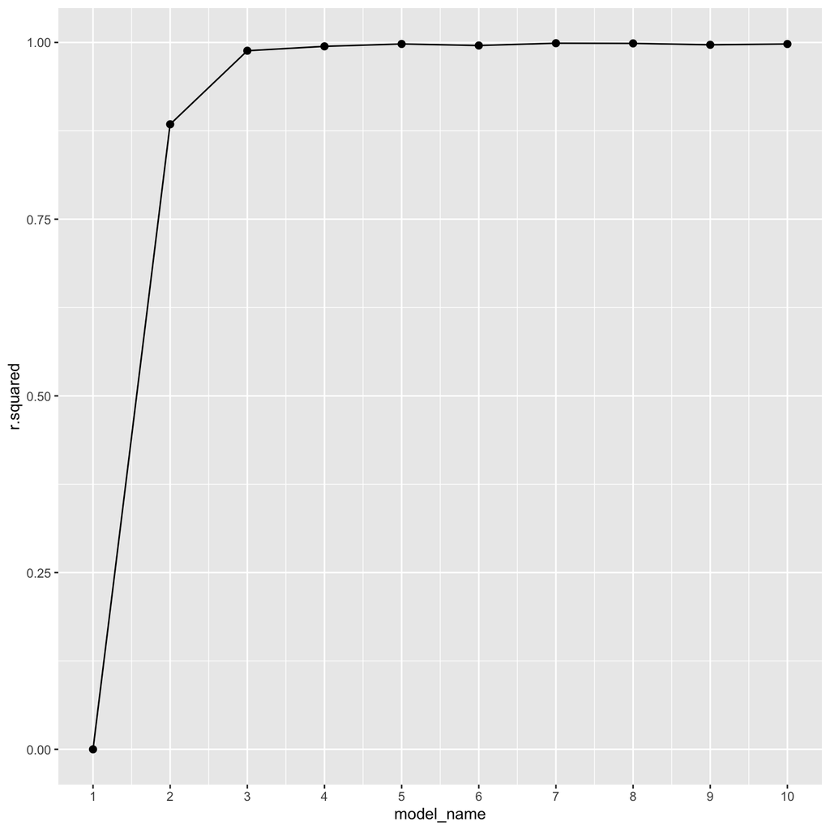

```r
metrics %>%
  ggplot(mapping = aes(x = model_name, y = r.squared)) +
  geom_line() + geom_point(size = 2) +
  scale_x_continuous(breaks = round(seq(1, 10, by = 1), 1))
```

It shows that all models have great accuracy except model 01 and 02. However, this view is clearly non-revealing. Thus, we also inspect the AIC values:

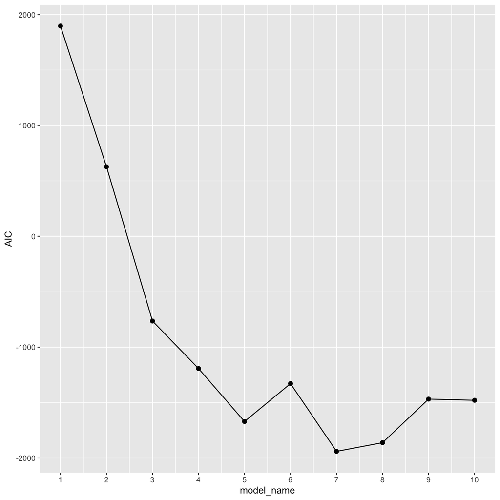

```r
metrics %>%
  ggplot(mapping = aes(x = model_name, y = AIC)) +
  geom_line() + geom_point(size = 2) +
  scale_x_continuous(breaks = round(seq(1, 10, by = 1), 1))
```

More importantly, we also include BIC in determining the best model since it is a training set only metric, and more conservative than AIC:

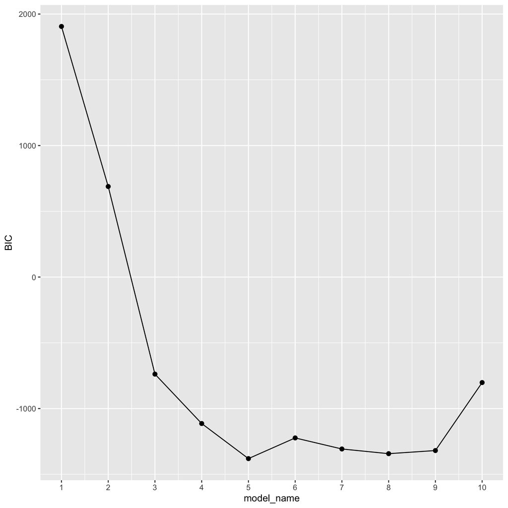

```r
metrics %>%
  ggplot(mapping = aes(x = model_name, y = BIC)) +
  geom_line() + geom_point(size = 2) +
  scale_x_continuous(breaks = round(seq(1, 10, by = 1), 1))
```

We also show the BIC values since the minimal value is hard to determine from the figure

```r
metrics[order(metrics$BIC),] %>% select("model_name", "BIC")
```

```
## # A tibble: 10 × 2
##    model_name    BIC
##         <int>  <dbl>
##  1          5 -1381.
##  2          8 -1343.
##  3          9 -1319.
##  4          7 -1307.
##  5          6 -1223.
##  6          4 -1114.
##  7         10  -802.
##  8          3  -738.
##  9          2   689.
## 10          1  1906.
```

```r
pred <- function(mod, test_data, y)
{
  pred_test <- as.vector(predict(mod, newdata = test_data))

  y_test <- test_data %>% dplyr::select(all_of(y)) %>% pull()

  test_metrics <- tibble::tibble(
    rmse = rmse_vec(y_test, pred_test),
    rsq = rsq_vec(y_test, pred_test)
  )
  test_metrics
}
```

```r
results <-
  purrr::map_df(models,
                pred,
                test_data = df_test,
                y = "y") %>%
  mutate(model_name = 1:10)
```

For the RMSE on the test set:

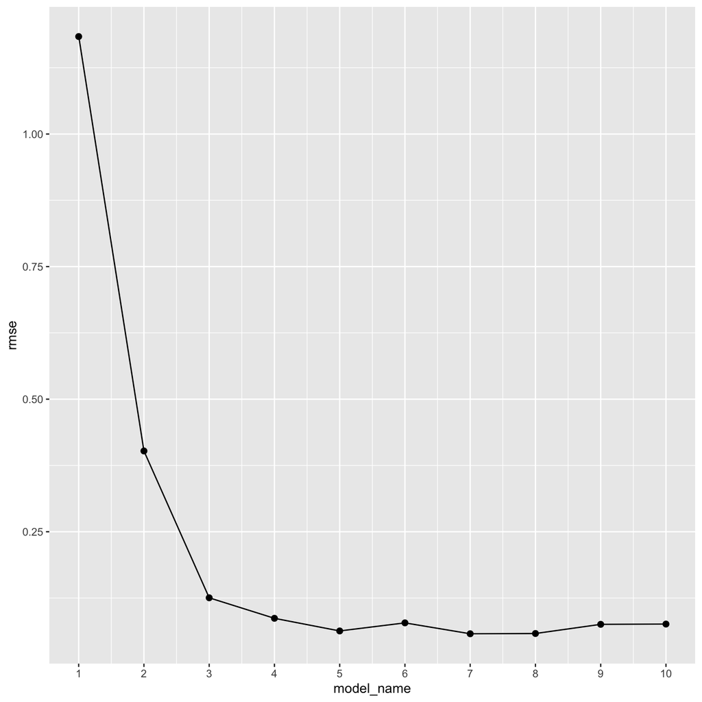

```r
results %>%
  ggplot(mapping = aes(x = model_name, y = rmse)) +
  geom_line() + geom_point(size = 2) +
  scale_x_continuous(breaks = round(seq(1, 10, by = 1), 1))
```

For the R squared on the test set:

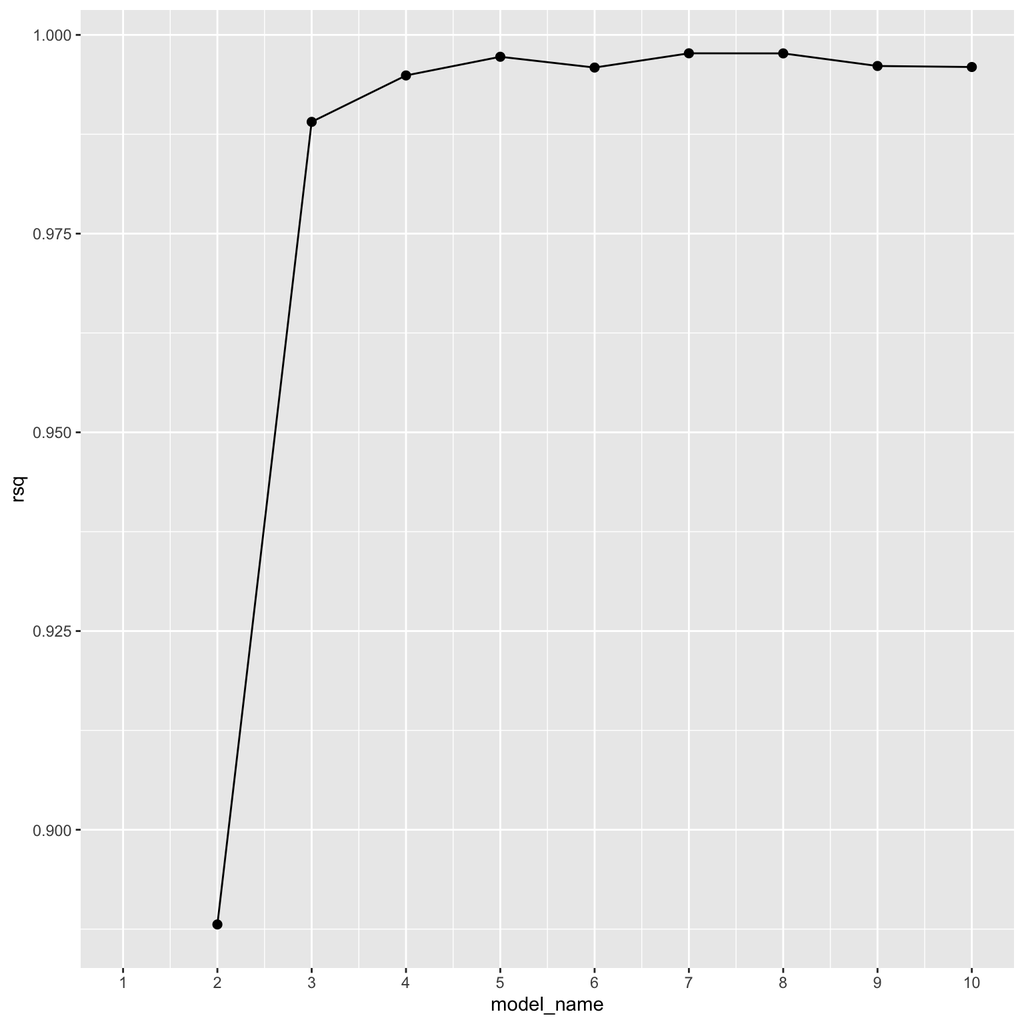

```r
results %>%
  ggplot(mapping = aes(x = model_name, y = rsq)) +
  geom_line() + geom_point(size = 2) +
  scale_x_continuous(breaks = round(seq(1, 10, by = 1), 1))
```

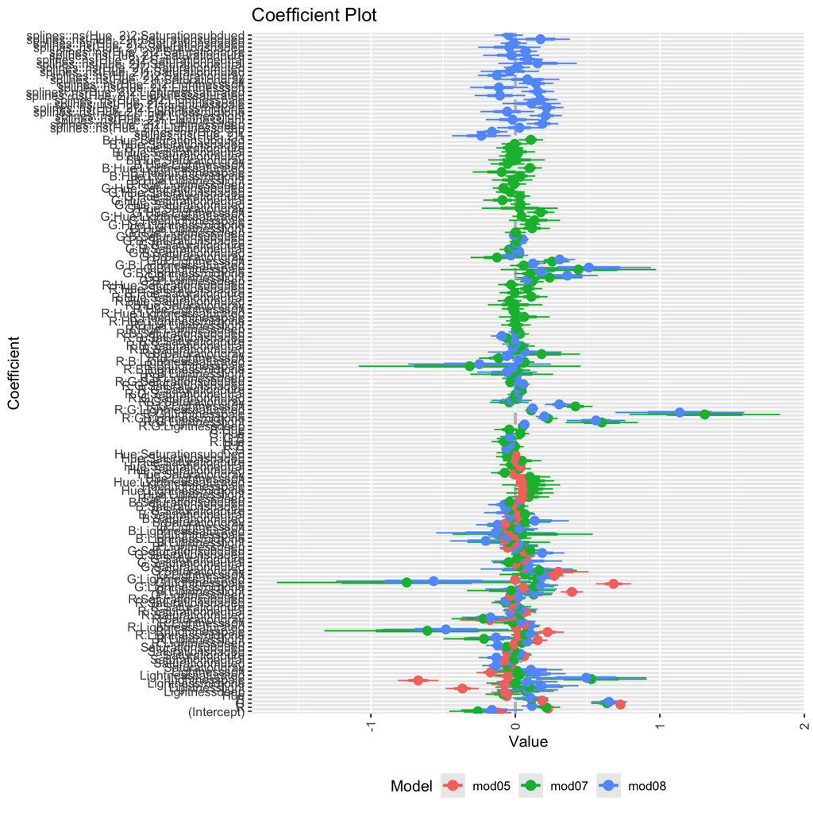

```r
coefplot::multiplot(mod05, mod07, mod08)
```

We provide some simple insights of the results:

For simpler variables shared by the 3 models, the coefficients identified by the 3 models are mostly close. However, more complex models (mod07, mod08) give a larger confidence interval.

For more complex variables, the variables are often not statistically significant. However, the coefficients identified by the 3 models differ.

By analyzing the coefficients, we conclude that the RGB data, categorical inputs are very important to the model. The interaction between 2 RGB data (R and G, or G and B) combined with a categorical input is also influential. Hue data, on the other hand, is much less important.

# 4. Bayesian linear models

In this section, we create Bayesian Linear Models with model 05 and model 08.

## 4.1 Fitting Bayesian Linear Models

We select model 05 and model 08 for the Bayesian linear models. Both are selected for its low complexity and good performance metrics (BIC, RMSE, etc.), indicating a good balance between the variance and bias. The design matrix and a reasonably strong prior (𝜏𝛽=1) is defined as below. For model 05:

```r
set.seed(0)
X05 <- model.matrix(y ~ (R + G + B + Hue) * (Lightness + Saturation), data = df)

info_05 <- list(
  yobs = df$y,
  design_matrix = X05,
  mu_beta = 0,
  tau_beta = 1,
  sigma_rate = 1
)
```

For model 08:

```r
X08 <- model.matrix(y ~ ( (R + G + B)^2 + splines::ns(Hue, 2) ) * (Lightness + Saturation), data = df)

info_08 <- list(
  yobs = df$y,
  design_matrix = X08,
  mu_beta = 0,
  tau_beta = 1,
  sigma_rate = 1
)
```

The following function calculates the log posterior:

```r
lm_logpost <- function(unknowns, my_info)
{
  # specify the number of unknown beta parameters
  length_beta <- ncol(my_info$design_matrix)

  # extract the beta parameters from the `unknowns` vector
  beta_v <- unknowns[1:length_beta]

  # extract the unbounded noise parameter, varphi
  lik_varphi <- unknowns[length_beta + 1]

  # back-transform from varphi to sigma
  lik_sigma <- exp(lik_varphi)

  # extract design matrix
  X <- my_info$design_matrix

  # calculate the linear predictor
  mu <- as.vector(X %*% as.matrix(beta_v))

  # evaluate the log-likelihood
  log_lik <- sum(dnorm(x = my_info$yobs, mean = mu, sd = lik_sigma, log = TRUE))

  # evaluate the log-prior
  log_prior_beta <- sum(dnorm(x = beta_v, mean = my_info$mu_beta, sd = my_info$tau_beta, log = TRUE))
  log_prior_sigma <- dexp(x = lik_sigma, rate = my_info$sigma_rate)

  # add the mean trend prior and noise prior together
  log_prior <- log_prior_beta + log_prior_sigma

  # account for the transformation
  log_derive_adjust <- lik_varphi

  # sum together
  log_lik + log_prior + log_derive_adjust
}
```

And a function for the Laplace approximation which returns the object consisting of the posterior mode, posterior covariance matrix, and the log-evidence:

```r
my_laplace <- function(start_guess, logpost_func, ...)
{
  # code adapted from the `LearnBayes`` function `laplace()`
  fit <- optim(start_guess,
               logpost_func,
               gr = NULL,
               ...,
               method = "BFGS",
               hessian = TRUE,
               control = list(fnscale = -1, maxit = 1001))

  mode <- fit$par
  post_var_matrix <- -solve(fit$hessian)
  p <- length(mode)
  int <- p/2 * log(2 * pi) + 0.5 * log(det(post_var_matrix)) + logpost_func(mode, ...)

  # package all of the results into a list
  list(mode = mode,
       var_matrix = post_var_matrix,
       log_evidence = int,
       converge = ifelse(fit$convergence == 0,
                         "YES",
                         "NO"),
       iter_counts = as.numeric(fit$counts[1]))
}
```

Here, We execute the Laplace approximation for the 2 models with an initial guess of 0:

```r
laplace_05 <- my_laplace(rep(0, ncol(X05)+1), lm_logpost, info_05)
laplace_08 <- my_laplace(rep(0, ncol(X08)+1), lm_logpost, info_08)
```

To test whether the Bayesian Linear Models have converged:

```r
laplace_05$converge
```

```
## [1] "YES"
```

```r
laplace_08$converge
```

```
## [1] "YES"
```

## 4.2 Model evaluation

To identify the best model, we use the log evidence as the metric:

```r
laplace_05$log_evidence
```

```
## [1] 812.5241
```

```r
laplace_08$log_evidence
```

```
## [1] -Inf
```

Thus, we show that model 05 is the best model.

We also use the following function to visualize the coefficient posteriors.

```r
set.seed(0)
viz_post_coefs <- function(post_means, post_sds, xnames)
{
  tibble::tibble(
    mu = post_means,
    sd = post_sds,
    x = xnames
  ) %>%
    mutate(x = factor(x, levels = xnames)) %>%
    ggplot(mapping = aes(x = x)) +
    geom_hline(yintercept = 0, color = 'grey', linetype = 'dashed') +
    geom_point(mapping = aes(y = mu)) +
    geom_linerange(mapping = aes(ymin = mu - 2 * sd,
                                 ymax = mu + 2 * sd,
                                 group = x)) +
    labs(x = 'feature', y = 'coefficient value') +
    coord_flip() +
    theme_bw()
}
```

For model 05:

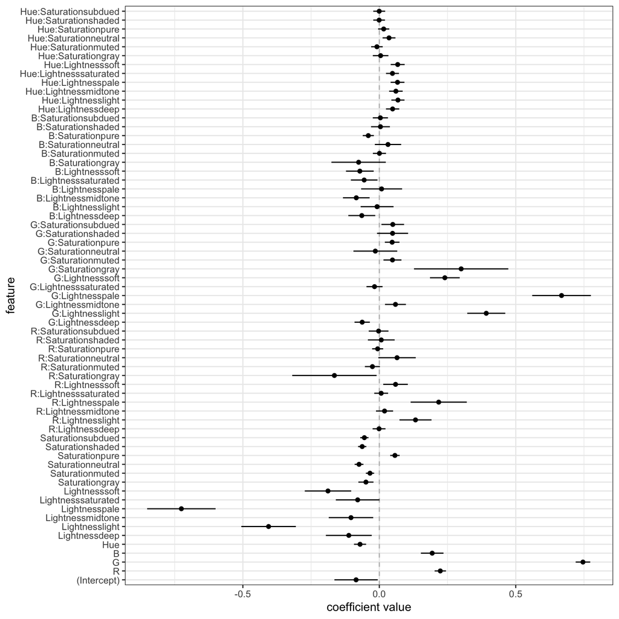

```r
post_means <- laplace_05$mode[1:ncol(X05)]
post_sd <- sqrt(diag(laplace_05$var_matrix)[1:ncol(X05)])
viz_post_coefs(post_means, post_sd, colnames(X05))
```

For model 05:

```r
sqrt(diag(laplace_05$var_matrix))
```

```
##  [1] 0.039706306 0.010355232 0.013337369 0.020725802 0.011086502 0.041991095
##  [7] 0.050012548 0.040730811 0.062677450 0.040039113 0.042481308 0.013785206
## [13] 0.007590921 0.008076354 0.008627450 0.007583889 0.007590976 0.011793798
## [19] 0.029293641 0.015679370 0.051465945 0.012680107 0.022553203 0.077308707
## [25] 0.013759293 0.034276677 0.010127614 0.024505053 0.018061859 0.014065083
## [31] 0.034792767 0.019139997 0.053816035 0.014743361 0.027246080 0.086406825
## [37] 0.016451945 0.040105433 0.013424679 0.028479212 0.020742566 0.024653063
## [43] 0.030150761 0.024457822 0.037520587 0.024379786 0.025391028 0.049789824
## [49] 0.011980114 0.024133677 0.010158449 0.017249997 0.013919247 0.012185123
## [55] 0.011983561 0.012382322 0.012651165 0.011810423 0.012805491 0.014276847
## [61] 0.010571331 0.011758577 0.010269637 0.010707248 0.010876775 0.025819328
```

As shown above, the standard deviations are low. To further study the uncertainty on the unknown likelihood noise 𝜎, we would need to generate posterior samples to study the posterior distribution on different features. The samples are generated with the following function:

```r
set.seed(0)
generate_lm_post_samples <- function(mvn_result, length_beta, num_samples)
{
  MASS::mvrnorm(n = num_samples,
                mu = mvn_result$mode,
                Sigma = mvn_result$var_matrix) %>%
    as.data.frame() %>% tibble::as_tibble() %>%
    purrr::set_names(c(sprintf("beta_%02d", 0:(length_beta-1)), "varphi")) %>%
    # back transform varphi to sigma!!!
    mutate(sigma =  exp(varphi))
}
```

For the samples for model 05:

```r
post_samples_05 <- generate_lm_post_samples(laplace_05, ncol(X05), 1000)
```

Same as in Part 1, we transform the samples into a long format for visualization purposes:

```r
post_samples_05_long <- post_samples_05 %>%
  pivot_longer(colnames(post_samples_05)) %>%
  as.data.frame()
```

The posterior histograms for different samples are shown below:

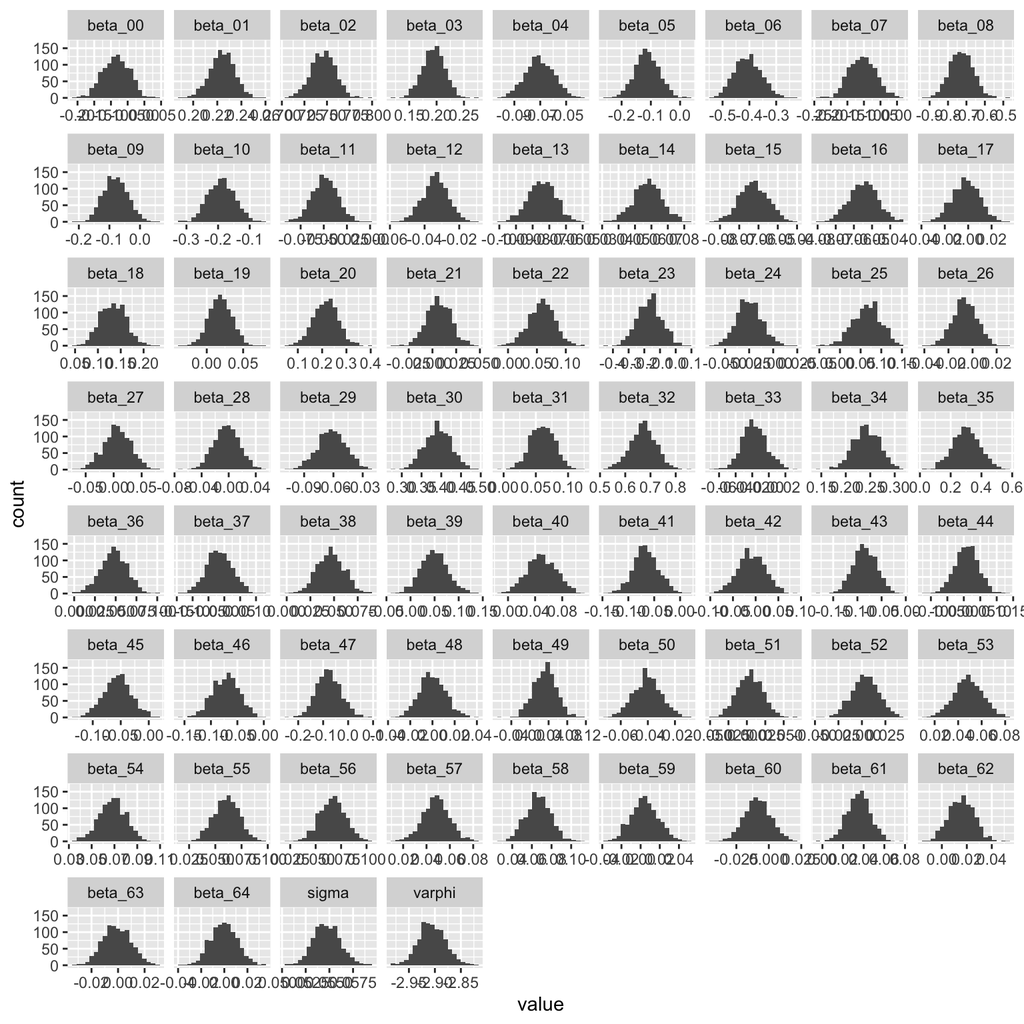

```r
post_samples_05_long %>%
  ggplot(mapping = aes(x = value)) +
  geom_histogram(bins = 20) +
  facet_wrap(~ name, nrow = 8, scale = "free_x")
```

From the distributions, we show that the coefficient predictions are densely distributed in a small interval. Also, the distribution resembles a Gaussian distribution.

# Linear prediction

Here, we use the 2 Linear Models (mod05 and mod08) to make predictions, we first prepare the grid for testing. To avoid a visualization grid too large, we make $ grids to study the output on R, G, B and Hue separately:

```r
viz_grid_R <- expand.grid(R = seq(min(df$R), max(df$R), length.out = 101),
                          G = mean(df$G),
                          B = mean(df$B),
                          Hue = mean(df$Hue),
                          Lightness = unique(df$Lightness),
                          Saturation = unique(df$Saturation),
                          KEEP.OUT.ATTRS = FALSE,
                          stringsAsFactors = FALSE) %>%
  as.data.frame() %>% tibble::as_tibble()
```

```r
viz_grid_G <- expand.grid(R = mean(df$R),
                          G = seq(min(df$G), max(df$G), length.out = 101),
                          B = mean(df$B),
                          Hue = mean(df$Hue),
                          Lightness = unique(df$Lightness),
                          Saturation = unique(df$Saturation),
                          KEEP.OUT.ATTRS = FALSE,
                          stringsAsFactors = FALSE) %>%
  as.data.frame() %>% tibble::as_tibble()
```

```r
viz_grid_B <- expand.grid(R = mean(df$R),
                          G = mean(df$G),
                          B = seq(min(df$B), max(df$B), length.out = 101),
                          Hue = mean(df$Hue),
                          Lightness = unique(df$Lightness),
                          Saturation = unique(df$Saturation),
                          KEEP.OUT.ATTRS = FALSE,
                          stringsAsFactors = FALSE) %>%
  as.data.frame() %>% tibble::as_tibble()
```

```r
viz_grid_H <- expand.grid(R = mean(df$R),
                          G = mean(df$G),
                          B = mean(df$B),
                          Hue = seq(min(df$Hue), max(df$Hue), length.out = 101),
                          Lightness = unique(df$Lightness),
                          Saturation = unique(df$Saturation),
                          KEEP.OUT.ATTRS = FALSE,
                          stringsAsFactors = FALSE) %>%
  as.data.frame() %>% tibble::as_tibble()
```

```r
tidy_predict <- function(mod, xnew)
{
  pred_df <- predict(mod, xnew, interval = "confidence") %>%
    as.data.frame() %>% tibble::as_tibble() %>%
    dplyr::select(pred = fit, ci_lwr = lwr, ci_upr = upr) %>%
    bind_cols(predict(mod, xnew, interval = 'prediction') %>%
                as.data.frame() %>% tibble::as_tibble() %>%
                dplyr::select(pred_lwr = lwr, pred_upr = upr))

  xnew %>% bind_cols(pred_df)
}
```

Therefore, we make predictions based on the new data for model 05:

```r
pred_lm_05_R <- tidy_predict(mod05, viz_grid_R)
pred_lm_05_G <- tidy_predict(mod05, viz_grid_G)
pred_lm_05_B <- tidy_predict(mod05, viz_grid_B)
pred_lm_05_H <- tidy_predict(mod05, viz_grid_H)
```

For model 05, we plot its predictive trend with R, G, B, and Hue (H) with respect to different categorical inputs:

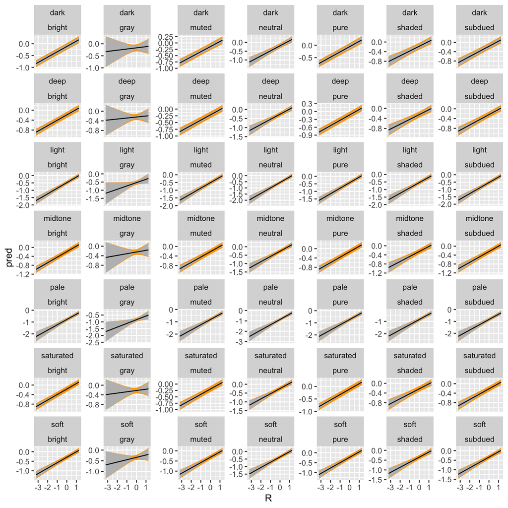

```r
pred_lm_05_R %>%
  ggplot(mapping = aes(x = R)) +
  geom_ribbon(mapping = aes(ymin = pred_lwr, ymax = pred_upr), fill = 'orange') +
  geom_ribbon(mapping = aes(ymin = ci_lwr, ymax = ci_upr), fill = 'grey') +
  geom_line(mapping = aes(y = pred)) +
  facet_wrap(~ Lightness*Saturation, nrow = 7, scale = "free_y")
```

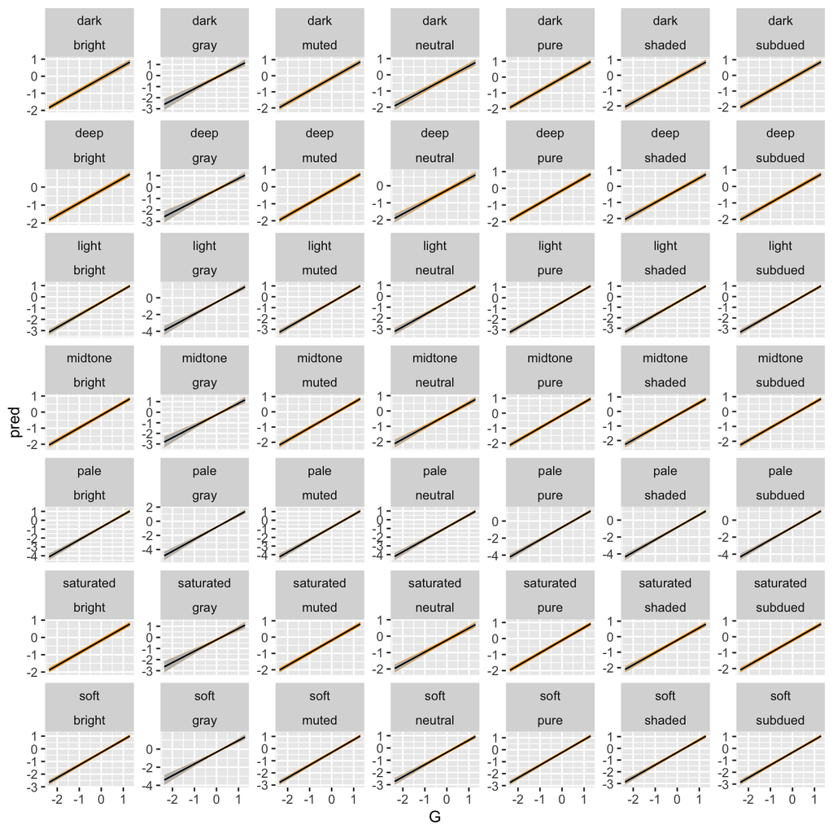

```r
pred_lm_05_G %>%
  ggplot(mapping = aes(x = G)) +
  geom_ribbon(mapping = aes(ymin = pred_lwr, ymax = pred_upr), fill = 'orange') +
  geom_ribbon(mapping = aes(ymin = ci_lwr, ymax = ci_upr), fill = 'grey') +
  geom_line(mapping = aes(y = pred)) +
  facet_wrap(~ Lightness*Saturation, nrow = 7, scale = "free_y")
```

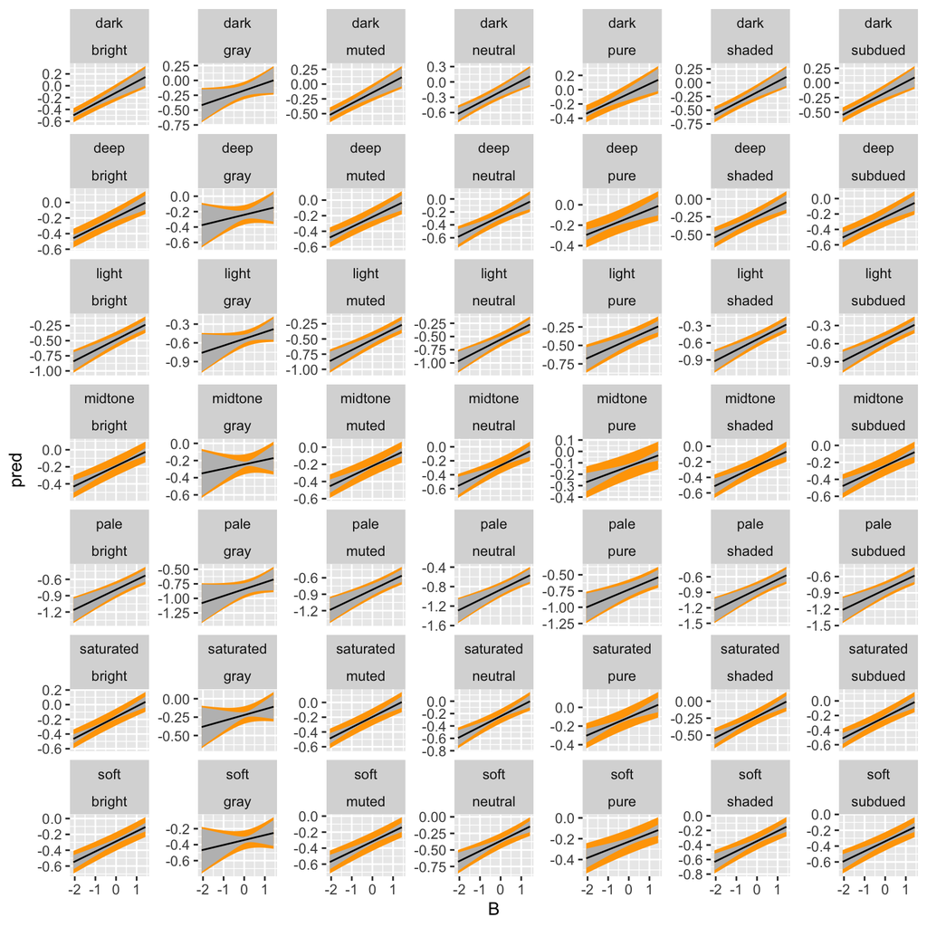

```r
pred_lm_05_B %>%
  ggplot(mapping = aes(x = B)) +
  geom_ribbon(mapping = aes(ymin = pred_lwr, ymax = pred_upr), fill = 'orange') +
  geom_ribbon(mapping = aes(ymin = ci_lwr, ymax = ci_upr), fill = 'grey') +
  geom_line(mapping = aes(y = pred)) +
  facet_wrap(~ Lightness*Saturation, nrow = 7, scale = "free_y")
```

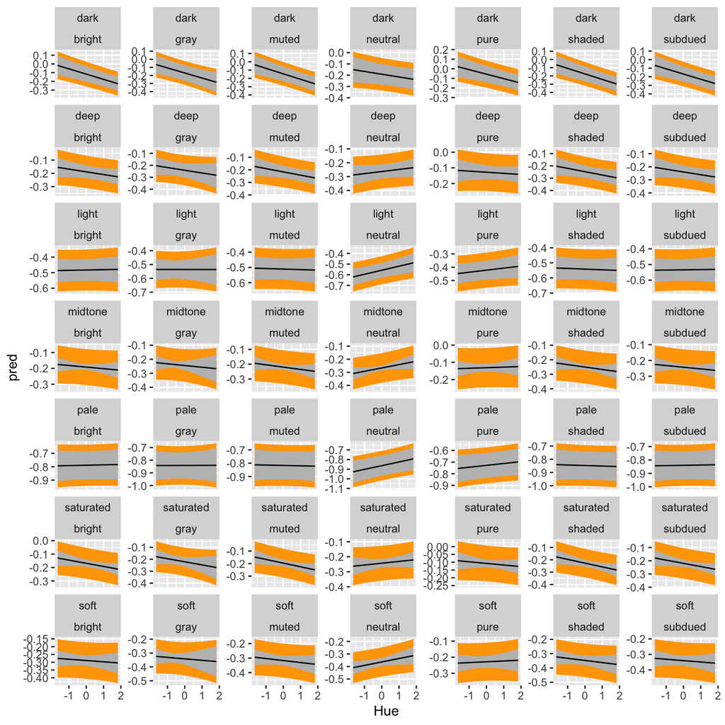

```r
pred_lm_05_H %>%
  ggplot(mapping = aes(x = Hue)) +
  geom_ribbon(mapping = aes(ymin = pred_lwr, ymax = pred_upr), fill = 'orange') +
  geom_ribbon(mapping = aes(ymin = ci_lwr, ymax = ci_upr), fill = 'grey') +
  geom_line(mapping = aes(y = pred)) +
  facet_wrap(~ Lightness*Saturation, nrow = 7, scale = "free_y")
```

Similarly, for model 08, we make predictions based on the new data:

```r
pred_lm_08_R <- tidy_predict(mod08, viz_grid_R)
pred_lm_08_G <- tidy_predict(mod08, viz_grid_G)
pred_lm_08_B <- tidy_predict(mod08, viz_grid_B)
pred_lm_08_H <- tidy_predict(mod08, viz_grid_H)
```

For model 08, we plot its predictive trend with R, G, B, and Hue (H) with respect to different categorical inputs:

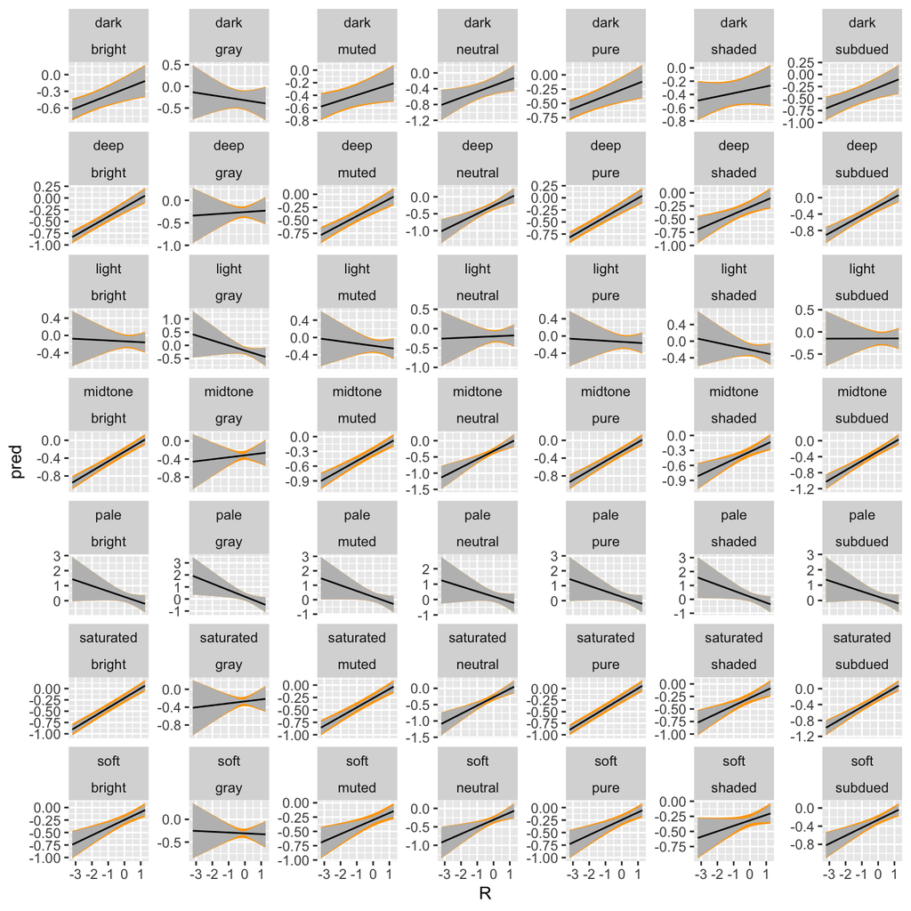

```r
pred_lm_08_R %>%
  ggplot(mapping = aes(x = R)) +
  geom_ribbon(mapping = aes(ymin = pred_lwr, ymax = pred_upr), fill = 'orange') +
  geom_ribbon(mapping = aes(ymin = ci_lwr, ymax = ci_upr), fill = 'grey') +
  geom_line(mapping = aes(y = pred)) +
  facet_wrap(~ Lightness*Saturation, nrow = 7, scale = "free_y")
```

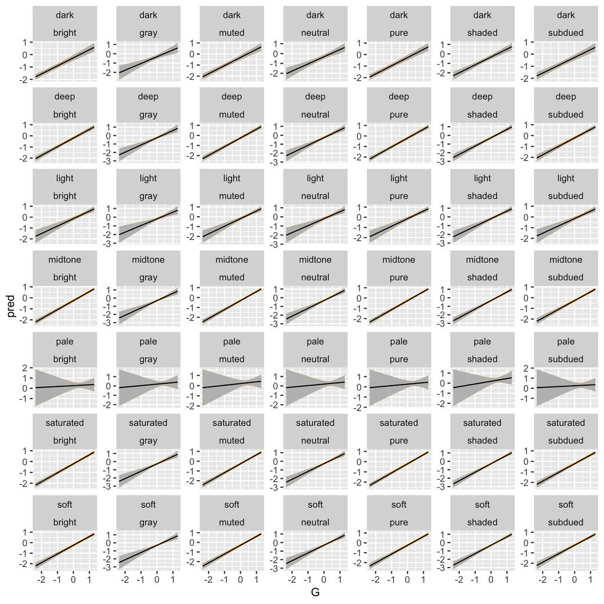

```r
pred_lm_08_G %>%
  ggplot(mapping = aes(x = G)) +
  geom_ribbon(mapping = aes(ymin = pred_lwr, ymax = pred_upr), fill = 'orange') +
  geom_ribbon(mapping = aes(ymin = ci_lwr, ymax = ci_upr), fill = 'grey') +
  geom_line(mapping = aes(y = pred)) +
  facet_wrap(~ Lightness*Saturation, nrow = 7, scale = "free_y")
```

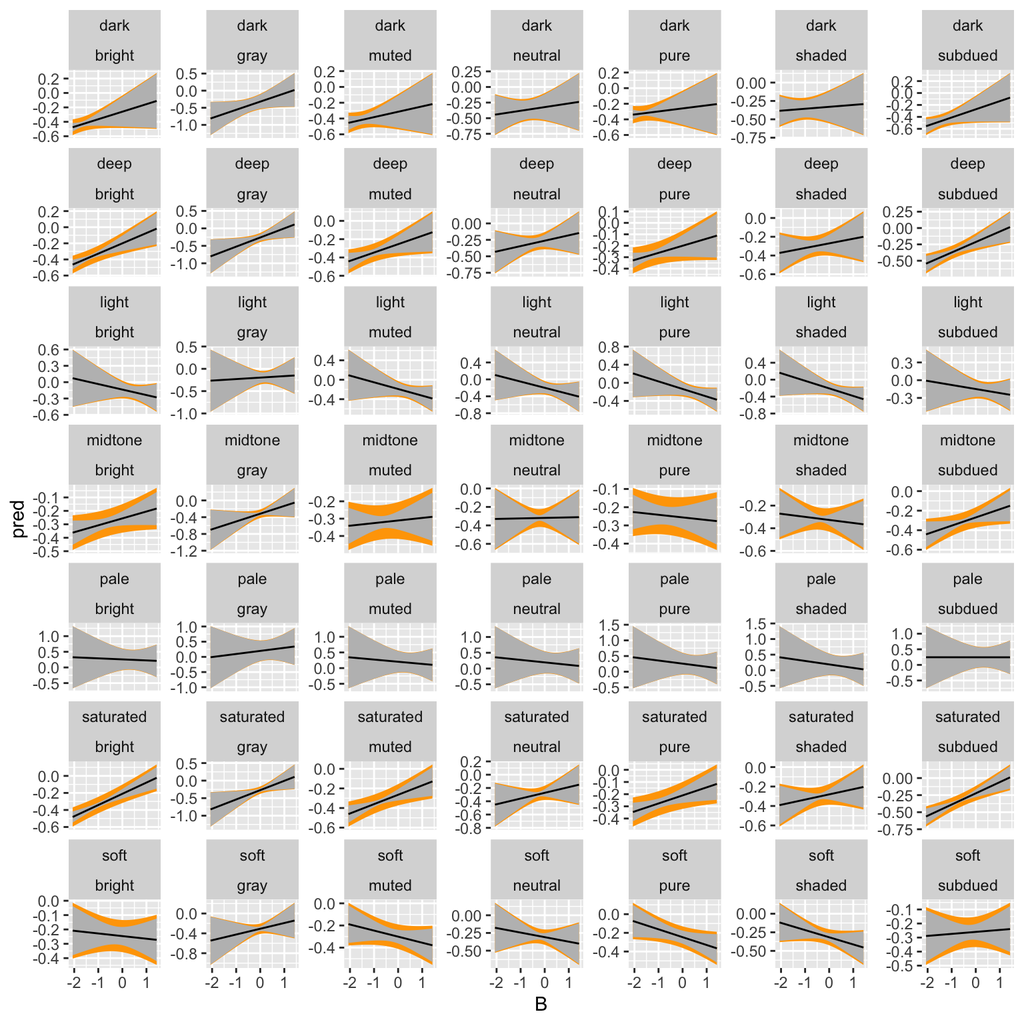

```r
pred_lm_08_B %>%
  ggplot(mapping = aes(x = B)) +
  geom_ribbon(mapping = aes(ymin = pred_lwr, ymax = pred_upr), fill = 'orange') +
  geom_ribbon(mapping = aes(ymin = ci_lwr, ymax = ci_upr), fill = 'grey') +
  geom_line(mapping = aes(y = pred)) +
  facet_wrap(~ Lightness*Saturation, nrow = 7, scale = "free_y")
```

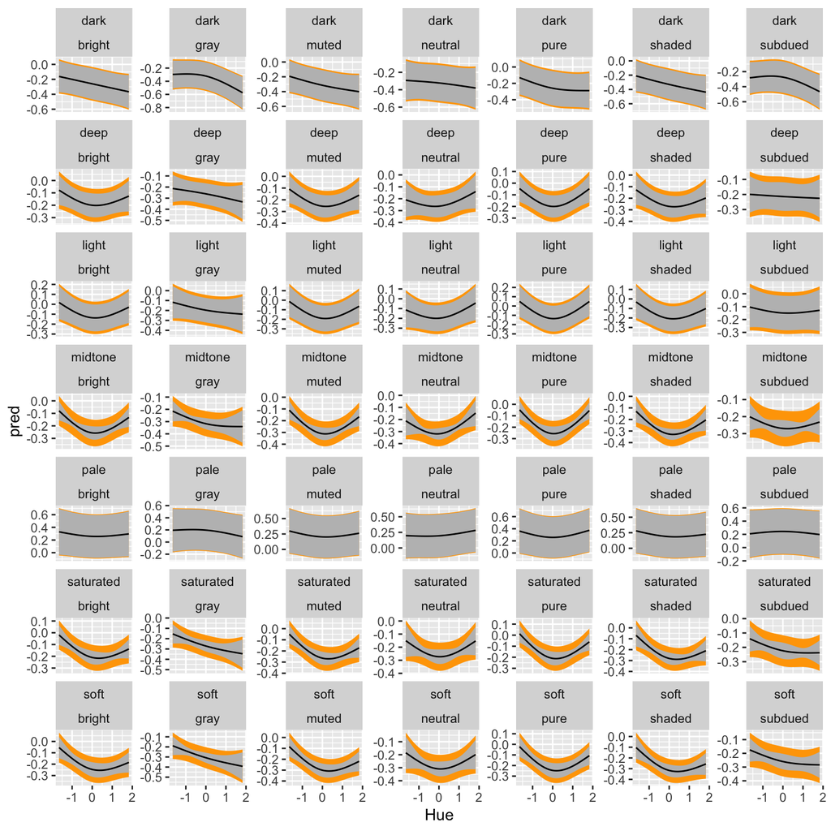

```r
pred_lm_08_H %>%
  ggplot(mapping = aes(x = Hue)) +
  geom_ribbon(mapping = aes(ymin = pred_lwr, ymax = pred_upr), fill = 'orange') +
  geom_ribbon(mapping = aes(ymin = ci_lwr, ymax = ci_upr), fill = 'grey') +
  geom_line(mapping = aes(y = pred)) +
  facet_wrap(~ Lightness*Saturation, nrow = 7, scale = "free_y")
```

# 6. Train/Tune

## 6.1 Model selection

To train and tune more complex model with resampling, we first specify the resampling scheme to be 10 fold with 3 repeats. The primary performance metric will be “RMSE”. We use caret to train and tune the models.

```r
set.seed(0)
my_ctrl <- trainControl(method = "repeatedcv", number = 10, repeats = 3)
my_metric <- 'RMSE'
```

Here, we define the models to be trained and tuned. For the linear models:

```r
set.seed(0)
lm_grid = expand.grid(intercept = seq(min(df$y), max(df$y), by = 0.1))

lm_04 <- train(y ~ R + G + B + Hue + Lightness + Saturation,
               data = df,
               method = "lm",
               metric = my_metric,
               preProcess = c("center", "scale"),
               trControl = my_ctrl,
               tuneGrid = lm_grid) # All categorical and continuous variables

lm_05 <- train(y ~ (R + G + B + Hue) * (Lightness + Saturation),
               data = df,
               method = "lm",
               metric = my_metric,
               preProcess = c("center", "scale"),
               trControl = my_ctrl,
               tuneGrid = lm_grid) # Interaction of categorical inputs with continuous inputs main effects

lm_06 <- train(y ~ (R + G + B + Hue)^2 + Lightness + Saturation,
               data = df,
               method = "lm",
               metric = my_metric,
               preProcess = c("center", "scale"),
               trControl = my_ctrl,
               tuneGrid = lm_grid) # Categorical inputs, main effect and all pairwise interactions

lm_08 <- train(y ~ ( (R + G + B)^2 + splines::ns(Hue, 2) ) * (Lightness + Saturation),
               data = df,
               method = "lm",
               metric = my_metric,
               preProcess = c("center", "scale"),
               trControl = my_ctrl,
               tuneGrid = lm_grid) # Non linear basis functions
```

For Elastic net models, we use the provided functions for training and tuning:

```r
set.seed(0)
enet_06_default <- train(y ~ (R + G + B + Hue)^2 + Lightness + Saturation,
                         data = df,
                         method = "glmnet",
                         metric = my_metric,
                         preProcess = c("center", "scale"),
                         trControl = my_ctrl)
enet_06_default
```

```
## glmnet
##
## 751 samples
##   6 predictor
##
## Pre-processing: centered (22), scaled (22)
## Resampling: Cross-Validated (10 fold, repeated 3 times)
## Summary of sample sizes: 678, 676, 676, 675, 675, 676, ...
## Resampling results across tuning parameters:
##
##   alpha  lambda       RMSE        Rsquared   MAE
##   0.10   0.002307121  0.07946745  0.9955054  0.05992949
##   0.10   0.023071209  0.08964055  0.9943814  0.06604871
##   0.10   0.230712094  0.16808261  0.9872365  0.13386537
##   0.55   0.002307121  0.07977012  0.9954696  0.06017941
##   0.55   0.023071209  0.09559810  0.9937468  0.07267910
##   0.55   0.230712094  0.22079532  0.9888477  0.17987459
##   1.00   0.002307121  0.08069534  0.9953643  0.06080584
##   1.00   0.023071209  0.10349623  0.9927758  0.08048661
##   1.00   0.230712094  0.29239966  0.9786183  0.24417588
##
## RMSE was used to select the optimal model using the smallest value.
## The final values used for the model were alpha = 0.1 and lambda = 0.002307121.
```

```r
set.seed(0)
enet_08_default <- train(y ~ ( (R + G + B)^2 + splines::ns(Hue, 2) ) * (Lightness + Saturation),
                         data = df,
                         method = "glmnet",
                         metric = my_metric,
                         preProcess = c("center", "scale"),
                         trControl = my_ctrl)
enet_08_default
```

```
## glmnet
##
## 751 samples
##   6 predictor
##
## Pre-processing: centered (116), scaled (116)
## Resampling: Cross-Validated (10 fold, repeated 3 times)
## Summary of sample sizes: 678, 676, 676, 675, 675, 676, ...
## Resampling results across tuning parameters:
##
##   alpha  lambda       RMSE        Rsquared   MAE
##   0.10   0.002307121  0.05668098  0.9976753  0.04092185
##   0.10   0.023071209  0.06645992  0.9968819  0.04788768
##   0.10   0.230712094  0.12832386  0.9928901  0.09367436
##   0.55   0.002307121  0.05811460  0.9975565  0.04173974
##   0.55   0.023071209  0.07771342  0.9959479  0.05809714
##   0.55   0.230712094  0.21822001  0.9897573  0.17866008
##   1.00   0.002307121  0.06045395  0.9973544  0.04352927
##   1.00   0.023071209  0.09280421  0.9942796  0.07209147
##   1.00   0.230712094  0.29239966  0.9786183  0.24417588
##
## RMSE was used to select the optimal model using the smallest value.
## The final values used for the model were alpha = 0.1 and lambda = 0.002307121.
```

From the results, we define the tuning grid(s):

```r
set.seed(0)
enet_06_grid <- expand.grid(alpha = seq(0.1, 1.0, length.out = 9),
                            lambda = exp(seq(log(min(enet_06_default$results$lambda)),
                            log(max(enet_06_default$results$lambda)),
                            length.out = 25)))


enet_08_grid <- expand.grid(alpha = seq(0.1, 1.0, length.out = 9),
                            lambda = exp(seq(log(min(enet_08_default$results$lambda)),
                            log(max(enet_08_default$results$lambda)),
                            length.out = 25)))
```

Here, we tune the Elastic Net models. For Enet_06:

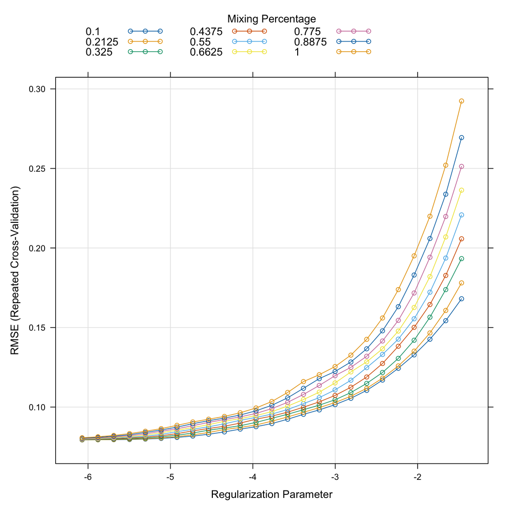

```r
set.seed(0)
enet_06_tune <- train(y ~ (R + G + B + Hue)^2 + Lightness + Saturation,
                      data = df,
                      method = "glmnet",
                      metric = my_metric,
                      preProcess = c("center", "scale"),
                      trControl = my_ctrl,
                      tuneGrid = enet_06_grid)
enet_06_tune %>% plot(xTrans = log)
```

For Enet_08:

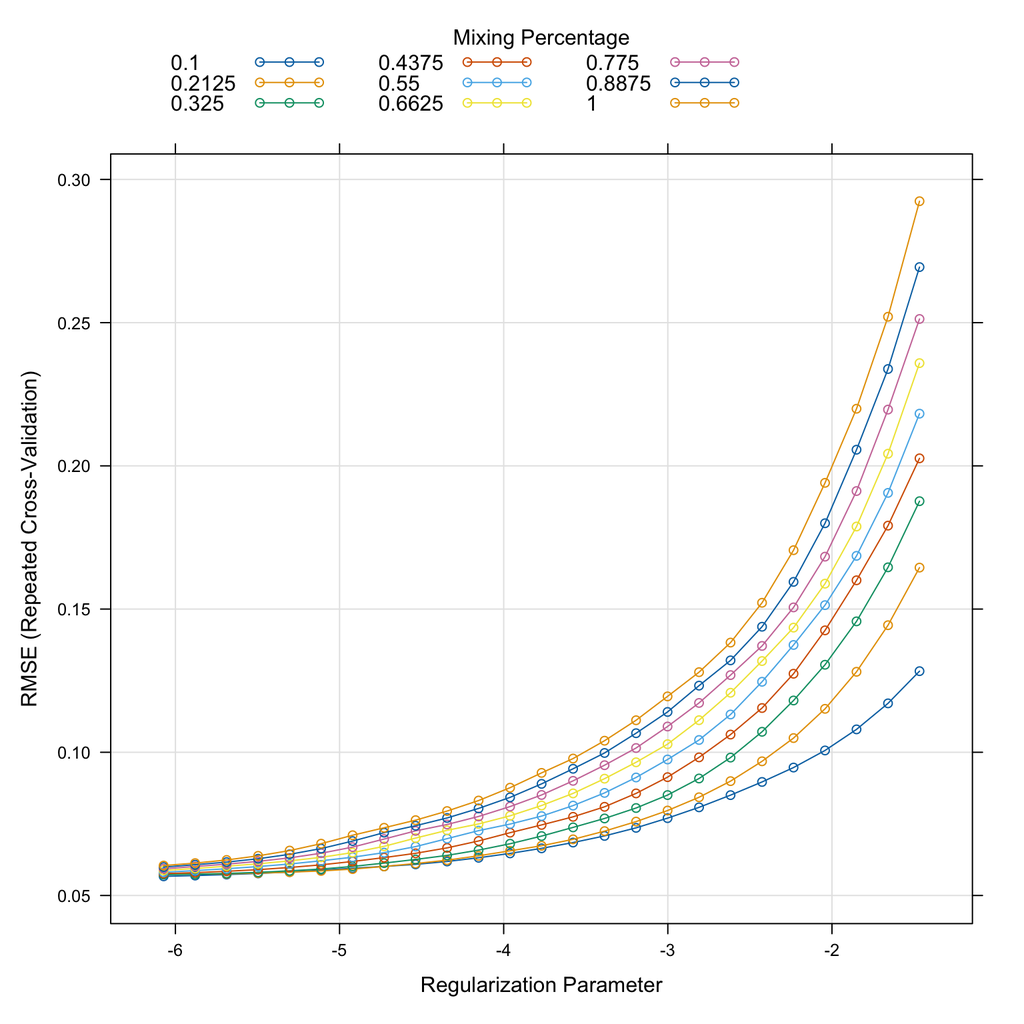

```r
set.seed(0)
enet_08_tune <- train(y ~ ( (R + G + B)^2 + splines::ns(Hue, 2) ) * (Lightness + Saturation),
                      data = df,
                      method = "glmnet",
                      metric = my_metric,
                      preProcess = c("center", "scale"),
                      trControl = my_ctrl,
                      tuneGrid = enet_08_grid)
enet_08_tune %>% plot(xTrans = log)
```

For the Neural Network:

```r
set.seed(0)
nnet_default <- train(y ~ .,
                      data = df,
                      method = 'nnet',
                      metric = my_metric,
                      preProcess = c('center', 'scale'),
                      trControl = my_ctrl,
                      trace = FALSE)
```

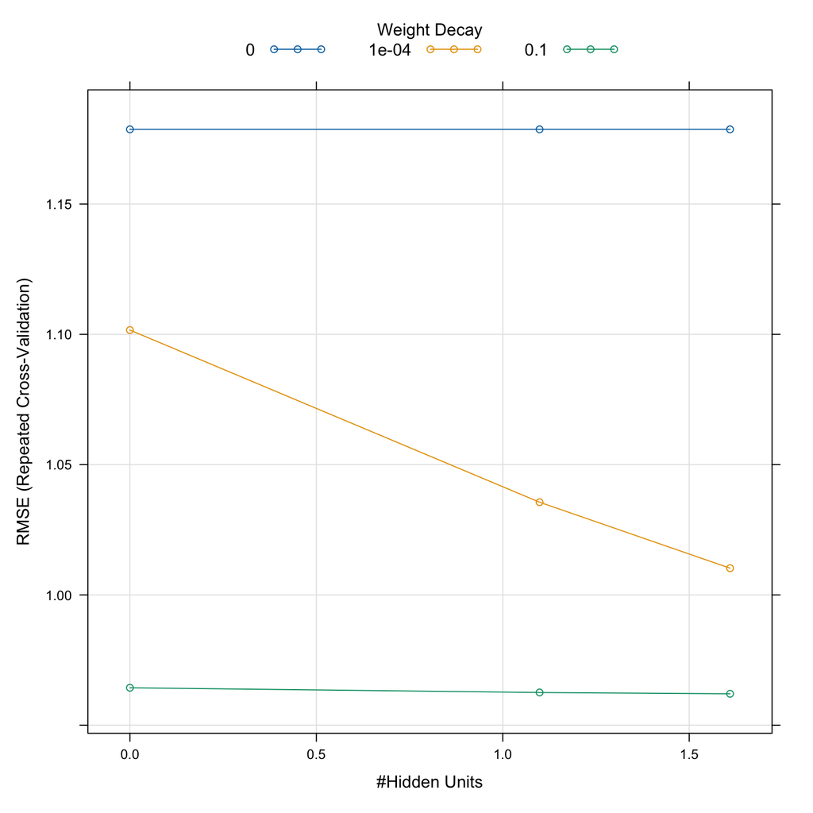

```r
nnet_default %>% plot(xTrans = log)
```

The tuning process:

```r
set.seed(0)
nnet_grid <- expand.grid(size = seq(1, 5, 1),
                         decay = seq(0.1, 1, 10))

nnet_tune <- train(y ~ .,
                   data = df,
                   method = 'nnet',
                   metric = my_metric,
                   preProcess = c('center', 'scale'),
                   trControl = my_ctrl,
                   trace = FALSE,
                   tuneGrid = nnet_grid)
```

For the Random Forest:

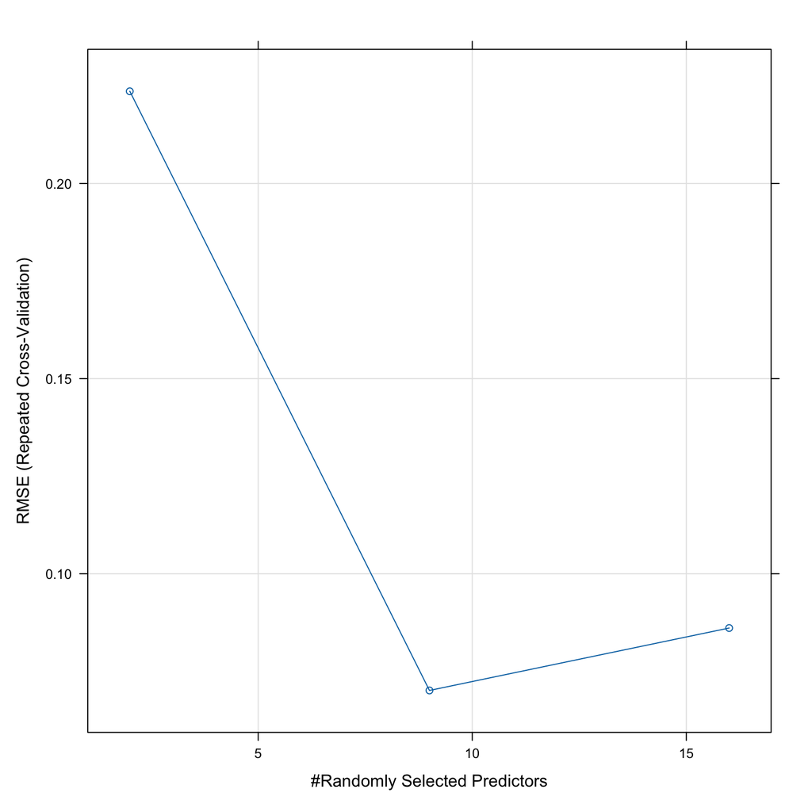

```r
set.seed(0)
rf_default <- train(y ~ .,
                    data = df,
                    method = 'rf',
                    metric = my_metric,
                    preProcess = c('center', 'scale'),
                    trControl = my_ctrl,
                    trace = FALSE,
                    importance = TRUE,
                    linout = TRUE)
plot(rf_default)
```

The tuning process:

```r
set.seed(0)
rf_grid <- expand.grid(mtry = seq(2, 8, by = 1))

rf_tune <- train(y ~ .,
                 data = df,
                 method = 'rf',
                 metric = my_metric,
                 preProcess = c('center', 'scale'),
                 trControl = my_ctrl,
                 trace = FALSE,
                 importance = TRUE,
                 tuneGrid = rf_grid,
                 linout = TRUE)
```

For the Gradient boosted tree:

```r
set.seed(0)
xgb_default <- train(y ~ .,
                     data = df,
                     method = 'xgbTree',
                     metric = my_metric,
                     trControl = my_ctrl,
                     preProcess = c("center", "scale"),
                     verbosity = 0,
                     nthread = 1)
```

The tuning process:

```r
set.seed(0)
xgb_grid <- expand.grid(nrounds = c(50, 100, 150, 200),
                        max_depth = c(2, 3, 5, 10),
                        eta = c(0.01, 0.1, 0.3),
                        gamma = c(0),
                        colsample_bytree = 1,
                        min_child_weight = 1,
                        subsample = 1
                        )

xgb_tune <- train(y ~ .,
                  data = df,
                  method = 'xgbTree',
                  metric = my_metric,
                  trControl = my_ctrl,
                  preProcess = c("center", "scale"),
                  verbosity = 0,
                  nthread = 1,
                  tuneGrid = xgb_grid)
```

Here, we also include (1) Support Vector Machine (SVM) and (2) K-Nearest Neighbors models:

For SVM

```r
set.seed(0)
svm_default <- train(y ~ .,
                     data = df,
                     method = "svmRadial",
                     metric = my_metric,
                     preProcess = c("center", "scale"),
                     trControl = my_ctrl)
svm_default
```

```
## Support Vector Machines with Radial Basis Function Kernel
##
## 751 samples
##   6 predictor
##
## Pre-processing: centered (16), scaled (16)
## Resampling: Cross-Validated (10 fold, repeated 3 times)
## Summary of sample sizes: 678, 676, 676, 675, 675, 676, ...
## Resampling results across tuning parameters:
##
##   C     RMSE       Rsquared   MAE
##   0.25  0.1394029  0.9868849  0.10489766
##   0.50  0.1180607  0.9902701  0.08991171
##   1.00  0.1019272  0.9927164  0.07821091
##
## Tuning parameter 'sigma' was held constant at a value of 0.04013761
## RMSE was used to select the optimal model using the smallest value.
## The final values used for the model were sigma = 0.04013761 and C = 1.
```

The tuning process:

```r
set.seed(0)
svm_grid <- expand.grid(sigma = c(svm_default$bestTune$sigma),
                        C = c(0.25, 0.5, 0.75, 1))

svm_tune <- train(y ~ .,
                  data = df,
                  method = "svmRadial",
                  metric = my_metric,
                  preProcess = c("center", "scale"),
                  trControl = my_ctrl,
                  tuneGrid = svm_grid)
```

For KNN:

```r
set.seed(0)
knn_default <- train(y ~ .,
                     data = df,
                     method = "knn",
                     metric = my_metric,
                     preProcess = c("center", "scale"),
                     trControl = my_ctrl)
knn_default
```

```
## k-Nearest Neighbors
##
## 751 samples
##   6 predictor
##
## Pre-processing: centered (16), scaled (16)
## Resampling: Cross-Validated (10 fold, repeated 3 times)
## Summary of sample sizes: 678, 676, 676, 675, 675, 676, ...
## Resampling results across tuning parameters:
##
##   k  RMSE       Rsquared   MAE
##   5  0.2835300  0.9429631  0.2181170
##   7  0.3167177  0.9288659  0.2475401
##   9  0.3400919  0.9174627  0.2685135
##
## RMSE was used to select the optimal model using the smallest value.
## The final value used for the model was k = 5.
```

The tuning process:

```r
set.seed(0)
knn_grid <- expand.grid(k = seq(1, 10, by = 1))

knn_tune <- train(y ~ .,
                  data = df,
                  method = "knn",
                  metric = my_metric,
                  preProcess = c("center", "scale"),
                  trControl = my_ctrl,
                  tuneGrid = knn_grid)
```

## 6.3 Model comparison

Here, we compare the models we have trained and tuned:

```r
set.seed(0)
caret_acc_compare <- resamples(list(lm_04 = lm_04,
                                    lm_05 = lm_05,
                                    lm_06 = lm_06,
                                    lm_08 = lm_08,
                                    ENET_06 = enet_06_tune,
                                    ENET_08 = enet_08_tune,
                                    NNET = nnet_tune,
                                    RF = rf_tune,
                                    XGB = xgb_tune,
                                    SVM = svm_tune,
                                    KNN = knn_tune))
```

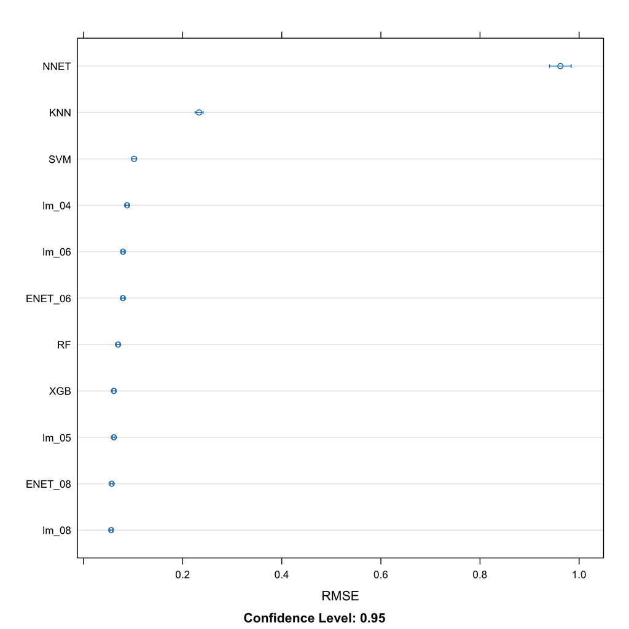

```r
dotplot(caret_acc_compare, metric = 'RMSE')
```

Thus, we show that the Linear Model 08 is the best model. We save the identified best model as “reg_best.rds”:

```r
lm_08 %>% readr::write_rds(here("Final project/Submit/reg_best.rds"))
```